# Matrix Algebra Homework

Venkata Sai Prakash Yerramsetti

2023-09-21

NOTE: Please do not use any of these functions - stats::prcomp(), FactoMiner::PCA(), ade4::dudi.pca(), ExPosition::epPCA() for completing this homework. You may use these functions to cross check your answers.

## Question 1

Consider the inbuilt dataset `vcd::Baseball`. You can use `help()` function to learn more about the data.

### Task 0: Identify categorical and numeric variables. Keep only the numeric variables in the dataset.

```r
# Include necessary libraries
library(tidyverse)
library(vcd)
# Import data
indata <- vcd::Baseball
head(indata)
```

```
##     name1    name2 atbat86 hits86 homer86 runs86 rbi86 walks86 years atbat hits
## 1      Al   Newman     185     37       1     23     8      21     2   214   42
## 2    Alan    Ashby     315     81       7     24    38      39    14  3449  835
## 3    Alan Trammell     574    159      21    107    75      59    10  4631 1300
## 4    Alan  Wiggins     239     60       0     30    11      22     6  1941  510
## 5    Alex  Trevino     202     53       4     31    26      27     9  1876  467
## 6 Alfredo  Griffin     594    169       4     74    51      35    11  4408 1133
##   homeruns runs rbi walks league86 div86 team86 posit86 outs86 assist86 error86
## 1        1   30   9    24        N     E    Mon      2B     76      127       7
## 2       69  321 414   375        N     W    Hou       C    632       43      10
## 3       90  702 504   488        A     E    Det      SS    238      445      22
## 4        4  309 103   207        A     E    Bal      2B    121      151       6
## 5       15  192 186   161        N     W     LA       C    304       45      11
## 6       19  501 336   194        A     W    Oak      SS    282      421      25
##     sal87 league87 team87
## 1  70.000        A    Min
## 2 475.000        N    Hou
## 3 517.143        A    Det
## 4 700.000        A    Bal
## 5 512.500        N     LA
## 6 750.000        A    Oak
```

```r
# Include only numeric variables. We want to keep the name and make that as row names for the dataset
indata_ <- indata[,-which(sapply(indata, class) == "factor")]
head(indata_)
```

```
##     name1    name2 atbat86 hits86 homer86 runs86 rbi86 walks86 years atbat hits
## 1      Al   Newman     185     37       1     23     8      21     2   214   42
## 2    Alan    Ashby     315     81       7     24    38      39    14  3449  835
## 3    Alan Trammell     574    159      21    107    75      59    10  4631 1300
## 4    Alan  Wiggins     239     60       0     30    11      22     6  1941  510
## 5    Alex  Trevino     202     53       4     31    26      27     9  1876  467
## 6 Alfredo  Griffin     594    169       4     74    51      35    11  4408 1133
##   homeruns runs rbi walks outs86 assist86 error86   sal87
## 1        1   30   9    24     76      127       7  70.000
## 2       69  321 414   375    632       43      10 475.000
## 3       90  702 504   488    238      445      22 517.143
## 4        4  309 103   207    121      151       6 700.000
## 5       15  192 186   161    304       45      11 512.500
## 6       19  501 336   194    282      421      25 750.000
```

```r
# Concatenating first and last name
indata_ <- indata_ %>% unite("fname_lname", c("name1", "name2"))
head(indata_)
```

```
##       fname_lname atbat86 hits86 homer86 runs86 rbi86 walks86 years atbat hits
## 1       Al_Newman     185     37       1     23     8      21     2   214   42
## 2      Alan_Ashby     315     81       7     24    38      39    14  3449  835
## 3   Alan_Trammell     574    159      21    107    75      59    10  4631 1300
## 4    Alan_Wiggins     239     60       0     30    11      22     6  1941  510
## 5    Alex_Trevino     202     53       4     31    26      27     9  1876  467
## 6 Alfredo_Griffin     594    169       4     74    51      35    11  4408 1133
##   homeruns runs rbi walks outs86 assist86 error86   sal87
## 1        1   30   9    24     76      127       7  70.000
## 2       69  321 414   375    632       43      10 475.000
## 3       90  702 504   488    238      445      22 517.143
## 4        4  309 103   207    121      151       6 700.000
## 5       15  192 186   161    304       45      11 512.500
## 6       19  501 336   194    282      421      25 750.000
```

```r
# Making name as row name instead of a column in the dataset
rownames(indata_) <- indata_[,1]

# Removing extra column
head(indata_)
```

```
##                     fname_lname atbat86 hits86 homer86 runs86 rbi86 walks86
## Al_Newman             Al_Newman     185     37       1     23     8      21
## Alan_Ashby           Alan_Ashby     315     81       7     24    38      39
## Alan_Trammell     Alan_Trammell     574    159      21    107    75      59
## Alan_Wiggins       Alan_Wiggins     239     60       0     30    11      22
## Alex_Trevino       Alex_Trevino     202     53       4     31    26      27
## Alfredo_Griffin Alfredo_Griffin     594    169       4     74    51      35
##                 years atbat hits homeruns runs rbi walks outs86 assist86
## Al_Newman           2   214   42        1   30   9    24     76      127
## Alan_Ashby         14  3449  835       69  321 414   375    632       43
## Alan_Trammell      10  4631 1300       90  702 504   488    238      445
## Alan_Wiggins        6  1941  510        4  309 103   207    121      151
## Alex_Trevino        9  1876  467       15  192 186   161    304       45
## Alfredo_Griffin    11  4408 1133       19  501 336   194    282      421
##                 error86   sal87
## Al_Newman             7  70.000
## Alan_Ashby           10 475.000
## Alan_Trammell        22 517.143
## Alan_Wiggins          6 700.000
## Alex_Trevino         11 512.500
## Alfredo_Griffin      25 750.000
```

```r
indata_ <- indata_[, -c(1)]

head(indata_)
```

```
##                 atbat86 hits86 homer86 runs86 rbi86 walks86 years atbat hits
## Al_Newman           185     37       1     23     8      21     2   214   42
## Alan_Ashby          315     81       7     24    38      39    14  3449  835
## Alan_Trammell       574    159      21    107    75      59    10  4631 1300
## Alan_Wiggins        239     60       0     30    11      22     6  1941  510
## Alex_Trevino        202     53       4     31    26      27     9  1876  467
## Alfredo_Griffin     594    169       4     74    51      35    11  4408 1133
##                 homeruns runs rbi walks outs86 assist86 error86   sal87
## Al_Newman              1   30   9    24     76      127       7  70.000
## Alan_Ashby            69  321 414   375    632       43      10 475.000
## Alan_Trammell         90  702 504   488    238      445      22 517.143
## Alan_Wiggins           4  309 103   207    121      151       6 700.000
## Alex_Trevino          15  192 186   161    304       45      11 512.500
## Alfredo_Griffin       19  501 336   194    282      421      25 750.000
```

```r
mean_sal87 <- mean(indata_$sal87, na.rm = TRUE)
indata_$sal87[is.na(indata_$sal87)] <- mean_sal87
head(indata_)
```

```
##                 atbat86 hits86 homer86 runs86 rbi86 walks86 years atbat hits
## Al_Newman           185     37       1     23     8      21     2   214   42
## Alan_Ashby          315     81       7     24    38      39    14  3449  835
## Alan_Trammell       574    159      21    107    75      59    10  4631 1300
## Alan_Wiggins        239     60       0     30    11      22     6  1941  510
## Alex_Trevino        202     53       4     31    26      27     9  1876  467
## Alfredo_Griffin     594    169       4     74    51      35    11  4408 1133
##                 homeruns runs rbi walks outs86 assist86 error86   sal87
## Al_Newman              1   30   9    24     76      127       7  70.000
## Alan_Ashby            69  321 414   375    632       43      10 475.000
## Alan_Trammell         90  702 504   488    238      445      22 517.143
## Alan_Wiggins           4  309 103   207    121      151       6 700.000
## Alex_Trevino          15  192 186   161    304       45      11 512.500
## Alfredo_Griffin       19  501 336   194    282      421      25 750.000
```

Here we have filled the null values with the mean value.

### Task 1: Generate the covariance matrix of the numeric variables. What can you say about the variables in the data

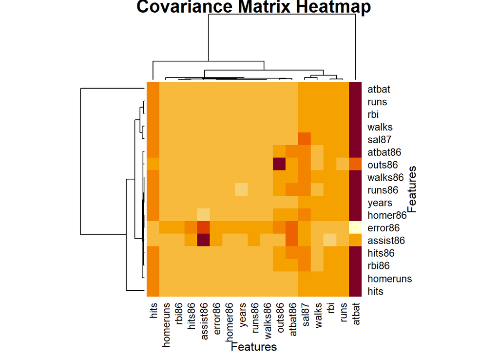

```r
covar_mat <- cov(indata_)
fea = "Features"
heatmap(covar_mat, main = "Covariance Matrix Heatmap", xlab = fea, ylab = fea)
```

```r
data <- indata_[, sapply(indata_, is.numeric)]
head(covar_mat)
```

```
##            atbat86    hits86   homer86    runs86     rbi86    walks86
## atbat86 23533.0883 6897.9083 791.18291 3645.1431 3293.7528 2223.60458
## hits86   6897.9083 2158.0430 227.43563 1114.8714  985.9214  644.57652
## homer86   791.1829  227.4356  75.84733  147.5431  194.8725   90.65086
## runs86   3645.1431 1114.8714 147.54310  677.2535  543.5539  412.34120
## rbi86    3293.7528  985.9214 194.87249  543.5539  684.7064  348.79850
## walks86  2223.6046  644.5765  90.65086  412.3412  348.7985  468.26045
##              years     atbat      hits  homeruns       runs       rbi     walks
## atbat86 35.7981753 83975.688 25372.630 3131.8607 13660.8015 12475.398 6805.7399
## hits86  10.2443838 24570.266  7777.631  812.3616  4063.1422  3591.352 1883.4738
## homer86  4.9902285  4491.248  1257.534  370.5586   763.4013  1021.451  542.2732
## runs86   0.5821772 11280.361  3488.672  511.6643  2178.5360  1786.170 1266.0590
## rbi86   18.8411312 17922.137  5278.102  997.2168  2826.3204  3428.296 1753.4045
## walks86 14.5478512 13940.298  3974.961  620.6409  2447.1370  2225.432 2453.2082
##             outs86  assist86    error86     sal87
## atbat86 13674.1669 7428.2586 343.996662 21411.952
## hits86   4051.2009 2037.3106  91.721735  7288.700
## homer86   691.6523 -126.7303   2.180647  1106.057
## runs86   2040.6548  785.5560  39.854115  3948.279
## rbi86    2520.7619  381.7096  32.223167  4283.365
## walks86  1819.3297  443.1987  17.829754  3549.451
```

### Task 2: Check if the covariance matrix is orthogonal

```r
covar_mat_trans <- t(covar_mat)
covar_mat_inv <- solve(covar_mat)
equal <- isTRUE(all.equal(covar_mat_trans, covar_mat_inv))
if (equal) {
  cat("orthogonal.")
} else {
  cat("not orthogonal.")
}
```

```
## not orthogonal.
```

**By this we can say that the matrix inverse is not equal to the matrix transpose

### Task 3: Compute the eigenvalues and eigenvectors for covariance matrix. What did you observe from your analysis?

```r
  eigen_result <- eigen(covar_mat)
  eigenvals <- eigen_result$values
  eigenvectors <- eigen_result$vectors
  cat("Eigenvalues:\n")
```

```
## Eigenvalues:
```

```r
  print(eigenvals)
```

```
##  [1] 6.137974e+06 1.450615e+05 6.736733e+04 2.875099e+04 1.612655e+04
##  [6] 1.308259e+04 8.769402e+03 3.840687e+03 1.393214e+03 1.697840e+02
## [11] 1.500922e+02 1.271914e+02 1.011511e+02 3.854496e+01 1.784920e+01
## [16] 7.570215e+00 2.546305e+00
```

```r
  cat("\nEigenvectors:\n")
```

```
##
## Eigenvectors:
```

```r
  print(eigenvectors)
```

```
##                [,1]         [,2]          [,3]         [,4]         [,5]
##  [1,] -1.495888e-02 -0.153481066  0.1252703338  0.648758065  0.481781739
##  [2,] -4.403410e-03 -0.051426037  0.0308516451  0.187431277  0.130479454
##  [3,] -8.058422e-04 -0.007390802  0.0056813439  0.007080869  0.039678021
##  [4,] -2.044210e-03 -0.028520229  0.0136238011  0.088570640  0.097887029
##  [5,] -3.198116e-03 -0.027962246  0.0203078413  0.062089494  0.105892755
##  [6,] -2.496537e-03 -0.022123331  0.0113196988  0.038928807  0.086580532
##  [7,] -1.824438e-03  0.001577499 -0.0003262114 -0.003720444 -0.002761816
##  [8,] -9.379418e-01  0.099598744  0.0271238772  0.035355835 -0.132503249
##  [9,] -2.630875e-01 -0.025159085  0.0028429737  0.041497336 -0.094815588
## [10,] -2.798588e-02 -0.021042500  0.0066466928 -0.092747018  0.296802808
## [11,] -1.328849e-01 -0.027144435 -0.0283245893 -0.022033717  0.217392471
## [12,] -1.280631e-01 -0.049989395  0.0277274275 -0.192175578  0.522669534
## [13,] -9.795346e-02  0.002011359 -0.0104207790 -0.191149219  0.457557234
## [14,] -7.778775e-03 -0.408069892  0.8909905520 -0.123527844 -0.126504821
```

[output cut: 57 more lines]

** It is positively correlated since the Eigen Values above decrease from the first principal component to the last principal component. **

### Task 4: Find the squareroot of the covariance matrix using the spectral decomposition method

```r
  eigen_result <- eigen(covar_mat)
  eigenvals <- eigen_result$values
  eigenvectors <- eigen_result$vectors
  sqrt_covar_mat <- eigenvectors %*% diag(sqrt(eigenvals)) %*% t(eigenvectors)
  print(" The Square Root of the Covariance Matrix is:")
```

```
## [1] " The Square Root of the Covariance Matrix is:"
```

```r
  print(sqrt_covar_mat)
```

```
##              [,1]        [,2]        [,3]       [,4]        [,5]        [,6]
##  [1,] 133.8039819 36.00512521  3.96182778 19.0902372 16.30175436 10.99724000
##  [2,]  36.0051252 20.07383931  0.80313343  7.6278570  5.48811997  2.52571283
##  [3,]   3.9618278  0.80313343  4.52082568  1.7509142  3.71138247  0.17130842
##  [4,]  19.0902372  7.62785697  1.75091423 11.4200445  3.40031288  3.38709405
##  [5,]  16.3017544  5.48811997  3.71138247  3.4003129 14.00392204  1.81831413
##  [6,]  10.9972400  2.52571283  0.17130842  3.3870940  1.81831413 13.15278733
##  [7,]  -0.6435868 -0.02286317 -0.02701002 -0.1519370 -0.01433763 -0.06650869
##  [8,]  28.6578473  7.28824547  1.41391852  3.0262258  5.70206080  4.05416619
##  [9,]  13.0661992  7.99031444 -0.30505209  1.4445890  2.13504591  1.01029731
## [10,]   4.2074227 -0.18436238  2.64037911  0.4752913  3.05657189  0.53492241
## [11,]  12.5082658  3.30279772  0.79708912  5.2360636  1.28566707  2.67871601
## [12,]   6.4567253  1.20811173  2.43091323  0.8125282  7.27738070  1.53257906
## [13,]  -5.6572129 -2.05735230  0.48473792  1.5046019 -0.02919824  8.92064011
## [14,]  28.4576806  8.04632766  1.52592366  3.8028015  5.42813465  4.01371475
```

[output cut: 39 more lines]

** (Original Matrix = eigenvectors * Diagonal values of eigenvalues * transpose of Eigen vectors ) this is used to recover the original matrix from the eigen values and vectors**

### Task 5: Based on the eigen decomposition in task 3, determine how many principal components you would select to reduce number of original features yet capture atleast 85% of the variability in the data?

```r
  sorted_eigenvals <- sort(eigenvals, decreasing = TRUE)
  total_variance <- sum(sorted_eigenvals)
  cum_variance <- cumsum(sorted_eigenvals) / total_variance
  num_comps <- which(cum_variance >= 0.85)[1]
  cat("Number of Principal Components required to capture at least 85% of variability is:", num_comps, "\n")
```

```
## Number of Principal Components required to capture at least 85% of variability is: 1
```

```r
  cat("total Proportion of Variance Explained by", num_comps, "Principal Components:", cum_variance[num_comps], "\n")
```

```
## total Proportion of Variance Explained by 1 Principal Components: 0.955627
```

```r
pca_result <- prcomp(indata_, center = TRUE, scale. = TRUE)
summary(pca_result)
```

```
## Importance of components:
##                           PC1    PC2     PC3     PC4     PC5     PC6     PC7
## Standard deviation     2.7775 2.0423 1.28737 0.95003 0.84359 0.75512 0.68839
## Proportion of Variance 0.4538 0.2454 0.09749 0.05309 0.04186 0.03354 0.02788
## Cumulative Proportion  0.4538 0.6992 0.79664 0.84973 0.89159 0.92514 0.95301
##                            PC8     PC9    PC10    PC11    PC12    PC13    PC14
## Standard deviation     0.50094 0.42506 0.35369 0.30409 0.24163 0.21945 0.15455
## Proportion of Variance 0.01476 0.01063 0.00736 0.00544 0.00343 0.00283 0.00141
## Cumulative Proportion  0.96777 0.97840 0.98576 0.99120 0.99463 0.99747 0.99887
##                           PC15    PC16    PC17
## Standard deviation     0.11598 0.06737 0.03485
## Proportion of Variance 0.00079 0.00027 0.00007
## Cumulative Proportion  0.99966 0.99993 1.00000
```

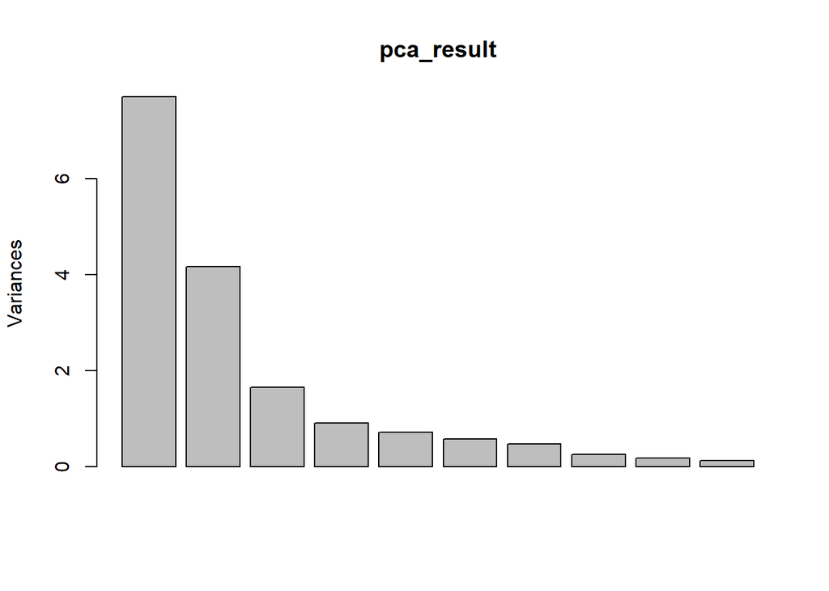

```r
plot(pca_result)
```

### Task 6: Compute the principal component vectors based on your selection in task 5. Comment on your interpretation of the PCs

```r
  select_eigenvectors <- eigenvectors[, 1:num_comps]
  cat("Principal Component Vectors (Eigenvectors):\n")
```

```
## Principal Component Vectors (Eigenvectors):
```

```r
  print(select_eigenvectors)
```

```
##  [1] -1.495888e-02 -4.403410e-03 -8.058422e-04 -2.044210e-03 -3.198116e-03
##  [6] -2.496537e-03 -1.824438e-03 -9.379418e-01 -2.630875e-01 -2.798588e-02
## [11] -1.328849e-01 -1.280631e-01 -9.795346e-02 -7.778775e-03  3.794798e-06
## [16]  1.734768e-04 -7.927879e-02
```

** The above is computing the principal Componet Vectors for the PC1 because I was only chosen for PC1.**

### Task 7: Perform task 1 to 6 using correlation matrix. Compare the results with the ones obtained from covariance matrix. Do the interpretation of the components differ?

```r
  #correlation matrix
  corr_mat <- cor(indata_)

  head(corr_mat)
```

```
##           atbat86    hits86   homer86    runs86     rbi86   walks86       years
## atbat86 1.0000000 0.9679388 0.5921985 0.9130603 0.8205392 0.6698451 0.047371739
## hits86  0.9679388 1.0000000 0.5621579 0.9221872 0.8110732 0.6412106 0.044766557
## homer86 0.5921985 0.5621579 1.0000000 0.6509882 0.8551222 0.4810143 0.116318335
## runs86  0.9130603 0.9221872 0.6509882 1.0000000 0.7982057 0.7322128 0.004541271
## rbi86   0.8205392 0.8110732 0.8551222 0.7982057 1.0000000 0.6159971 0.146168128
## walks86 0.6698451 0.6412106 0.4810143 0.7322128 0.6159971 1.0000000 0.136474971
##             atbat      hits  homeruns      runs       rbi     walks    outs86
## atbat86 0.2355264 0.2527170 0.2366590 0.2665340 0.2440531 0.1661231 0.3175498
## hits86  0.2275649 0.2558149 0.2027120 0.2617869 0.2320050 0.1518182 0.3106735
## homer86 0.2218821 0.2206266 0.4932269 0.2623606 0.3519790 0.2331537 0.2829229
## runs86  0.1864974 0.2048297 0.2279132 0.2505561 0.2059759 0.1821682 0.2793472
## rbi86   0.2946884 0.3082011 0.4417712 0.3232846 0.3931837 0.2509136 0.3431864
## walks86 0.2771748 0.2806711 0.3324732 0.3384780 0.3086314 0.4245071 0.2995147
##           assist86    error86     sal87
## atbat86  0.3538240 0.35211719 0.3424742
## hits86   0.3204549 0.31003782 0.3849737
## homer86 -0.1063286 0.03931765 0.3116150
## runs86   0.2205674 0.24047503 0.3722573
## rbi86    0.1065910 0.19336973 0.4016465
## walks86  0.1496561 0.12938206 0.4024653
```

** The major distinction between covariance and correlation is scaling; covariance values are sets of real numbers, whereas correlation values are in the [-1 to 1] range. Values close to -1 have a negative correlation, those close to 0 have no correlation, and those close to 1 have a positive correlation.**

```r
  #finding orthogonal
  orthogonal <- isTRUE(all.equal(t(corr_mat) %*% corr_mat, diag(ncol(corr_mat))))

  if (orthogonal) {
    cat("correlation matrix is orthogonal.\n")
  } else {
    cat("correlation matrix is not orthogonal.\n")
  }
```

```
## correlation matrix is not orthogonal.
```

```r
  #eigenvector and eigenvalues
  eigen_result <- eigen(corr_mat)
  eigenvals <- eigen_result$values
  eigenvectors <- eigen_result$vectors
  cat("Eigenvalues:\n")
```

```
## Eigenvalues:
```

```r
  print(eigenvals)
```

```
##  [1] 7.714602331 4.170965492 1.657331377 0.902556764 0.711640738 0.570205234
##  [7] 0.473881437 0.250945261 0.180673955 0.125097247 0.092469165 0.058383501
## [13] 0.048158300 0.023885757 0.013450269 0.004538691 0.001214481
```

```r
  cat("\nEigenvectors:\n")
```

```
##
## Eigenvectors:
```

```r
  print(eigenvectors)
```

```
##              [,1]        [,2]        [,3]         [,4]         [,5]        [,6]
##  [1,] -0.21142255  0.36697504  0.05464389 -0.104915706 -0.072300559 -0.11137615
##  [2,] -0.20788928  0.36306593  0.03449147 -0.091693422 -0.149329450 -0.06038110
##  [3,] -0.20372592  0.22801882 -0.33284130 -0.180197865  0.456678505  0.22505277
##  [4,] -0.20520935  0.36406178 -0.06212267 -0.153847253 -0.188446940 -0.09368447
##  [5,] -0.23964523  0.30087932 -0.16710003 -0.121351753  0.255194175  0.12765520
##  [6,] -0.21500866  0.23895172 -0.06427253  0.013743689 -0.403228936 -0.34969894
##  [7,] -0.26858368 -0.27349498  0.09702835 -0.015946584  0.047515011 -0.10283324
##  [8,] -0.31660840 -0.20486433  0.12544505 -0.003569922  0.004900921 -0.06588719
##  [9,] -0.31773642 -0.19489622  0.12148020  0.012517963 -0.019253145 -0.04615968
## [10,] -0.30232936 -0.14533873 -0.10936492 -0.061602894  0.272302491  0.11939367
## [11,] -0.32446511 -0.18602045  0.09019372 -0.019666078 -0.051721633 -0.05550177
## [12,] -0.32483540 -0.18527298  0.01632757 -0.003159895  0.141017162  0.03974827
## [13,] -0.30220636 -0.20153629  0.06611333 -0.004324201 -0.097596850 -0.19023997
## [14,] -0.09015624  0.16184539 -0.17200405  0.860972241  0.239993916 -0.32337257
```

[output cut: 57 more lines]

```r
  #sqrt
  eigen_result <- eigen(corr_mat)
  eigenvals <- eigen_result$values
  eigenvectors <- eigen_result$vectors
  sqrt_corr_mat <- eigenvectors %*% diag(sqrt(eigenvals)) %*% t(eigenvectors)
  print("Square Root of Covariance Matrix:")
```

```
## [1] "Square Root of Covariance Matrix:"
```

```r
  print(sqrt_corr_mat)
```

```
##               [,1]         [,2]         [,3]        [,4]       [,5]
##  [1,]  0.621928447  0.460641494  0.181219864  0.37755766 0.30839072
##  [2,]  0.460641494  0.628802754  0.147280732  0.40677643 0.31442015
##  [3,]  0.181219864  0.147280732  0.786783516  0.24316946 0.40928458
##  [4,]  0.377557665  0.406776425  0.243169455  0.66055133 0.26842579
##  [5,]  0.308390718  0.314420146  0.409284583  0.26842579 0.66964467
##  [6,]  0.233175304  0.198243288  0.128667699  0.29335596 0.19236755
##  [7,] -0.016417642 -0.013256113  0.002342673 -0.04550540 0.01951300
##  [8,]  0.071254213  0.054609924  0.026730485  0.02818020 0.05966629
##  [9,]  0.067215293  0.088434534  0.016674225  0.03260263 0.06780676
## [10,]  0.047664417  0.006946338  0.217510749  0.03121534 0.14266002
## [11,]  0.069892367  0.064598996  0.041683372  0.08431598 0.05671901
## [12,]  0.047400342  0.046666568  0.094033311  0.01777619 0.13435887
## [13,] -0.001566434 -0.004401042  0.046791393  0.03700718 0.02549759
## [14,]  0.101961013  0.095390013  0.088825332  0.06403284 0.11359694
```

[output cut: 57 more lines]

```r
  sorted_eigenvals <- sort(eigenvals, decreasing = TRUE)
  total_corr <- sum(sorted_eigenvals)
  cum_corr <- cumsum(sorted_eigenvals) / total_corr
  num_comps <- which(cum_corr >= 0.85)[1]
  print(cum_corr)
```

```
##  [1] 0.4538001 0.6991510 0.7966411 0.8497327 0.8915939 0.9251354 0.9530108
##  [8] 0.9677723 0.9784002 0.9857588 0.9911982 0.9946325 0.9974653 0.9988704
## [15] 0.9996616 0.9999286 1.0000000
```

```r
  cat("Number of Principal Components required for capturing of at least 85% of variability is:", num_comps, "\n")
```

```
## Number of Principal Components required for capturing of at least 85% of variability is: 5
```

```r
  cat("total Proportion of Variance Explained by", num_comps, "Principal Components:", cum_variance[num_comps], "\n")
```

[output not shown]

```r
  select_eigenvectors <- eigenvectors[, 1:num_comps]
  cat("Principal Component Vectors :\n")
```

```
## Principal Component Vectors :
```

```r
  print(select_eigenvectors)
```

```
##              [,1]        [,2]        [,3]         [,4]         [,5]
##  [1,] -0.21142255  0.36697504  0.05464389 -0.104915706 -0.072300559
##  [2,] -0.20788928  0.36306593  0.03449147 -0.091693422 -0.149329450
##  [3,] -0.20372592  0.22801882 -0.33284130 -0.180197865  0.456678505
##  [4,] -0.20520935  0.36406178 -0.06212267 -0.153847253 -0.188446940
##  [5,] -0.23964523  0.30087932 -0.16710003 -0.121351753  0.255194175
##  [6,] -0.21500866  0.23895172 -0.06427253  0.013743689 -0.403228936
##  [7,] -0.26858368 -0.27349498  0.09702835 -0.015946584  0.047515011
##  [8,] -0.31660840 -0.20486433  0.12544505 -0.003569922  0.004900921
##  [9,] -0.31773642 -0.19489622  0.12148020  0.012517963 -0.019253145
## [10,] -0.30232936 -0.14533873 -0.10936492 -0.061602894  0.272302491
## [11,] -0.32446511 -0.18602045  0.09019372 -0.019666078 -0.051721633
## [12,] -0.32483540 -0.18527298  0.01632757 -0.003159895  0.141017162
## [13,] -0.30220636 -0.20153629  0.06611333 -0.004324201 -0.097596850
## [14,] -0.09015624  0.16184539 -0.17200405  0.860972241  0.239993916
## [15,] -0.01763076  0.18952050  0.65634475  0.018184345  0.012271374
## [16,] -0.01031095  0.22943577  0.56671302  0.128422010  0.372416028
## [17,] -0.22226487  0.03430042 -0.05430864  0.383144165 -0.441995128
```